# alpha_vantage_project

| \| Top \| Getting Data \| Splits & Dividends \| The Datetime Index \| Frequency & Intervals \| Technical Indicators \| Foreign Exchange \| Cryptocurrencies \| |  |  |
| --- | --- | --- |

| Alpha Vantage API Overview |  |  |
| --- | --- | --- |
| \| [Alpha Vantage](https://www.alphavantage.co/) \| [alpha_vantage Module](https://pypi.org/project/alpha-vantage/#description) \| |  |  |

| **Evan Marie online**: \| [EvanMarie.com](https://www.evanmarie.com/)\| EvanMarie@Proton.me \| [Linked In](https://www.linkedin.com/in/evanmarie/) \| [GitHub](https://github.com/EvanMarie) \| [Hugging… |  |  |  |  |
| --- | --- | --- | --- | --- |

**Pros and Cons of Alpha Vantage:**  
**Pros**

- Free (5 calls per minute, 500 per day), and premium is available
- Large datasets for crypto, stocks, etc
- 50+ technical indicators (such as SMA, Bollinger Bands)

**Cons**

- Limited call requests
- API key needed, compared to yfinance that requires no key
- No high frequency or real time data
- No data for bonds, funds, indexes, or commodities

```python
from helpers_02_04 import *
import_all()
plt.style.use('pinks.mplstyle')
from alpha_vantage.timeseries import TimeSeries
%matplotlib inline
```

```python
%%html
<style>
a:link {color: #35193e !important; font-weight: 600 !important;}
a:visited {color: #35193e !important; font-weight: 600 !important;}
</style>
```

| \| Top \| Getting Data \| Splits & Dividends \| The Datetime Index \| Frequency & Intervals \| Technical Indicators \| Foreign Exchange \| Cryptocurrencies \| |  |  |
| --- | --- | --- |

| Getting Data from Alpha Vantage |  |  |
| --- | --- | --- |

```python
api_key = ''
ts = TimeSeries(key = api_key, output_format = 'pandas')
ts
```

```
<alpha_vantage.timeseries.TimeSeries at 0x7fb80b19cb20>
```

| Time Series Object |  |  |
| --- | --- | --- |

```python
pretty('TimeSeries()')
help(ts)
```

| TimeSeries() |
| --- |

```
Help on TimeSeries in module alpha_vantage.timeseries object:

class TimeSeries(alpha_vantage.alphavantage.AlphaVantage)
 |  TimeSeries(key=None, output_format='json', treat_info_as_error=True, indexing_type='date', proxy=None, rapidapi=False)
 |  This class implements all the api calls to times series
 |  Method resolution order:
 |      TimeSeries
 |      alpha_vantage.alphavantage.AlphaVantage
 |      builtins.object
 |  Methods defined here:
 |  get_daily(self, symbol, outputsize='compact')
 |      Return daily time series in two json objects as data and
 |      meta_data. It raises ValueError when problems arise
 |      Keyword Arguments:
 |          symbol:  the symbol for the equity we want to get its data
 |          outputsize:  The size of the call, supported values are
 |              'compact' and 'full; the first returns the last 100 points in the
 |              data series, and 'full' returns the full-length daily times
 |              series, commonly above 1MB (default 'compact')
 |  get_daily_adjusted(self, symbol, outputsize='compact')
 |      Return daily adjusted (date, daily open, daily high, daily low,
 |      daily close, daily split/dividend-adjusted close, daily volume)
 |      time series in two json objects as data and
 |      meta_data. It raises ValueError when problems arise
 |      Keyword Arguments:
 |          symbol:  the symbol for the equity we want to get its data
 |          outputsize:  The size of the call, supported values are
 |              'compact' and 'full; the first returns the last 100 points in the
 |              data series, and 'full' returns the full-length daily times
 |              series, commonly above 1MB (default 'compact')
 |  get_intraday(self, symbol, interval='15min', outputsize='compact')
 |      Return intraday time series in two json objects as data and
 |      meta_data. It raises ValueError when problems arise
 |      Keyword Arguments:
 |          symbol:  the symbol for the equity we want to get its data
 |          interval:  time interval between two conscutive values,
 |              supported values are '1min', '5min', '15min', '30min', '60min'
 |              (default '15min')
 |          outputsize:  The size of the call, supported values are
 |              'compact' and 'full; the first returns the last 100 points in the
```

[output cut: 75 more lines]

```
 |              * 5 = Triangular Moving Average (TRIMA),
 |              * 6 = T3 Moving Average,
 |              * 7 = Kaufman Adaptive Moving Average (KAMA),
 |              * 8 = MESA Adaptive Moving Average (MAMA)
 |  set_proxy(self, proxy=None)
 |      Set a new proxy configuration
 |      Keyword Arguments:
 |          proxy: Dictionary mapping protocol or protocol and hostname to
 |          the URL of the proxy.
 |  ----------------------------------------------------------------------
 |  Data descriptors inherited from alpha_vantage.alphavantage.AlphaVantage:
 |  __dict__
 |      dictionary for instance variables (if defined)
 |  __weakref__
 |      list of weak references to the object (if defined)
```

```python
GE = ts.get_daily("GE")
```

```python
pretty('ts.get_daily()')
help(ts.get_daily)
```

| ts.get_daily() |
| --- |

```
Help on method get_daily in module alpha_vantage.timeseries:

get_daily(symbol, outputsize='compact') method of alpha_vantage.timeseries.TimeSeries instance
    Return daily time series in two json objects as data and
    meta_data. It raises ValueError when problems arise

    Keyword Arguments:
        symbol:  the symbol for the equity we want to get its data
        outputsize:  The size of the call, supported values are
            'compact' and 'full; the first returns the last 100 points in the
            data series, and 'full' returns the full-length daily times
            series, commonly above 1MB (default 'compact')
```

| Resulting Data & Types |  |  |
| --- | --- | --- |

```python
type(GE)
```

```
tuple
```

```python
len(GE)
```

```
2
```

```python
GE[0][0:5]
```

| date | 1. open | 2. high | 3. low | 4. close | 5. volume |
| --- | --- | --- | --- | --- | --- |
| 2023-02-03 | 83.51 | 83.69 | 81.82 | 81.96 | 5,778,181.00 |
| 2023-02-02 | 82.19 | 84.03 | 81.90 | 83.94 | 8,293,043.00 |
| 2023-02-01 | 80.27 | 82.47 | 80.01 | 82.32 | 7,272,316.00 |
| 2023-01-31 | 80.45 | 80.91 | 79.47 | 80.48 | 6,883,537.00 |
| 2023-01-30 | 82.41 | 82.75 | 80.67 | 80.83 | 5,726,899.00 |

```python
pretty('GE[1] contains meta information')
GE[1]
```

| GE[1] contains meta information |
| --- |

```
{'1. Information': 'Daily Prices (open, high, low, close) and Volumes',
 '2. Symbol': 'GE',
 '3. Last Refreshed': '2023-02-03',
 '4. Output Size': 'Compact',
 '5. Time Zone': 'US/Eastern'}
```

```python
pretty('GE[0] contains the DataFrame')
df_overview(GE[0])
```

| GE[0] contains the DataFrame |
| --- |

DataFrame Columns

|  | 1. open | 2. high | 3. low | 4. close | 5. volume |
| --- | --- | --- | --- | --- | --- |
| datatype | float64 | float64 | float64 | float64 | float64 |
| missing values | 0 | 0 | 0 | 0 | 0 |
| count | 100.00 | 100.00 | 100.00 | 100.00 | 100.00 |
| mean | 76.78 | 77.95 | 75.89 | 77.06 | 6,827,626.88 |
| std | 7.74 | 7.67 | 7.71 | 7.70 | 2,520,143.25 |
| min | 62.64 | 63.29 | 61.88 | 61.91 | 1,894,075.00 |
| 25% | 69.97 | 71.00 | 68.94 | 70.16 | 4,948,897.75 |
| 50% | 78.06 | 80.34 | 77.54 | 79.06 | 6,390,139.00 |
| 75% | 83.29 | 84.03 | 81.95 | 83.50 | 7,993,457.25 |
| max | 87.70 | 88.38 | 87.35 | 88.14 | 16,784,586.00 |

DataFrame Key Points

| total rows | 100 |
| --- | --- |
| total columns | 5 |
| column names | 1. open, 2. high, 3. low, 4. close, 5. volume |
| index start | 2023-02-03 00:00:00 |
| index end | 2022-09-13 00:00:00 |
| total missing values | 0 |

| DataFrame Head and Tail |
| --- |

head(3)

| date | 1. open | 2. high | 3. low | 4. close | 5. volume |
| --- | --- | --- | --- | --- | --- |
| 2023-02-03 | 83.51 | 83.69 | 81.82 | 81.96 | 5,778,181.00 |
| 2023-02-02 | 82.19 | 84.03 | 81.90 | 83.94 | 8,293,043.00 |
| 2023-02-01 | 80.27 | 82.47 | 80.01 | 82.32 | 7,272,316.00 |

tail(3)

| date | 1. open | 2. high | 3. low | 4. close | 5. volume |
| --- | --- | --- | --- | --- | --- |
| 2022-09-15 | 69.78 | 70.79 | 68.75 | 68.91 | 4,927,334.00 |
| 2022-09-14 | 70.70 | 71.00 | 68.68 | 70.03 | 6,210,344.00 |
| 2022-09-13 | 73.26 | 73.86 | 70.62 | 70.84 | 7,210,803.00 |

| Setting Specific Time Periods |  |  |
| --- | --- | --- |

```python
GE = ts.get_daily('GE', outputsize = 'compact')[0]
```

| *compact* returns the last 100 timestamps (default) |  |  |
| --- | --- | --- |

```python
see(GE.head(3), 'outputsize = "compact"')
```

| outputsize = "compact" |
| --- |

| date | 1. open | 2. high | 3. low | 4. close | 5. volume |
| --- | --- | --- | --- | --- | --- |
| 2023-02-03 | 83.51 | 83.69 | 81.82 | 81.96 | 5,778,181.00 |
| 2023-02-02 | 82.19 | 84.03 | 81.90 | 83.94 | 8,293,043.00 |
| 2023-02-01 | 80.27 | 82.47 | 80.01 | 82.32 | 7,272,316.00 |

```python
pretty(len(GE), 'len(GE)')
```

| len(GE) |
| --- |
| 100 |

```python
GE_full = ts.get_daily('GE', outputsize = 'full')[0]
```

[output not shown]

```python
see(GE_full.head(3), 'outputsize = "full"')
```

| outputsize = "full" |
| --- |

| date | 1. open | 2. high | 3. low | 4. close | 5. volume |
| --- | --- | --- | --- | --- | --- |
| 2023-02-03 | 83.51 | 83.69 | 81.82 | 81.96 | 5,778,181.00 |
| 2023-02-02 | 82.19 | 84.03 | 81.90 | 83.94 | 8,293,043.00 |
| 2023-02-01 | 80.27 | 82.47 | 80.01 | 82.32 | 7,272,316.00 |

```python
pretty(f'{len(GE_full):,}', 'len(GE_full)')
```

| len(GE_full) |
| --- |
| 5,853 |

| \| Top \| Getting Data \| Splits & Dividends \| The Datetime Index \| Frequency & Intervals \| Technical Indicators \| Foreign Exchange \| Cryptocurrencies \| |  |  |
| --- | --- | --- |

| Stock Splits & Dividends |  |  |
| --- | --- | --- |

```python
import yfinance as yf
```

```python
ticker = 'GE'
```

```python
GE_full = ts.get_daily(ticker, outputsize = 'full')[0]
```

```python
pretty('GE_full meta informtation')
ts.get_daily(ticker, outputsize = 'full')[1]
```

| GE_full meta informtation |
| --- |

```
{'1. Information': 'Daily Prices (open, high, low, close) and Volumes',
 '2. Symbol': 'GE',
 '3. Last Refreshed': '2023-02-03',
 '4. Output Size': 'Full size',
 '5. Time Zone': 'US/Eastern'}
```

| Observing differences in importing from Alpha Vantage versus yfinance |  |  |
| --- | --- | --- |

```python
see(GE_full.head(3), 'Alpha Vantage Version, outputsize = "full"')
```

| Alpha Vantage Version, outputsize = "full" |
| --- |

| date | 1. open | 2. high | 3. low | 4. close | 5. volume |
| --- | --- | --- | --- | --- | --- |
| 2023-02-03 | 83.51 | 83.69 | 81.82 | 81.96 | 5,778,181.00 |
| 2023-02-02 | 82.19 | 84.03 | 81.90 | 83.94 | 8,293,043.00 |
| 2023-02-01 | 80.27 | 82.47 | 80.01 | 82.32 | 7,272,316.00 |

| *Adj Close* - Adjusted for stock splits and dividends |  |  |
| --- | --- | --- |

```python
see(yf.download(ticker, start = GE_full.index[0]),
	'yfinance version, same time period')
```

```
[*********************100%***********************]  1 of 1 completed
```

| yfinance version, same time period |
| --- |

| Date | Open | High | Low | Close | Adj Close | Volume |
| --- | --- | --- | --- | --- | --- | --- |
| 2023-02-03 | 83.51 | 83.69 | 81.82 | 81.96 | 81.96 | 5777400 |

| *ts.get_daily_adjusted()* - also returns the dividend amount and split coefficient |  |  |
| --- | --- | --- |

```python
GE_adj = ts.get_daily_adjusted(ticker, outputsize = 'full')[0]
```

```python
pretty('ts.get_daily_adjusted()')
help(ts.get_daily_adjusted)
```

| ts.get_daily_adjusted() |
| --- |

```
Help on method get_daily_adjusted in module alpha_vantage.timeseries:

get_daily_adjusted(symbol, outputsize='compact') method of alpha_vantage.timeseries.TimeSeries instance
    Return daily adjusted (date, daily open, daily high, daily low,
    daily close, daily split/dividend-adjusted close, daily volume)
    time series in two json objects as data and
    meta_data. It raises ValueError when problems arise

    Keyword Arguments:
        symbol:  the symbol for the equity we want to get its data
        outputsize:  The size of the call, supported values are
            'compact' and 'full; the first returns the last 100 points in the
            data series, and 'full' returns the full-length daily times
            series, commonly above 1MB (default 'compact')
```

```python
pretty('GE_adj meta informtation')
ts.get_daily_adjusted(ticker, outputsize = 'full')[1]
```

| GE_adj meta informtation |
| --- |

```
{'1. Information': 'Daily Time Series with Splits and Dividend Events',
 '2. Symbol': 'GE',
 '3. Last Refreshed': '2023-02-03',
 '4. Output Size': 'Full size',
 '5. Time Zone': 'US/Eastern'}
```

```python
df_overview(GE_adj, title = "GE 'get_daily_adjusted'")
```

GE 'get_daily_adjusted' Columns

|  | 1. open | 2. high | 3. low | 4. close | 5. adjusted close | 6. volume | 7. dividend amount | 8. split coefficient |
| --- | --- | --- | --- | --- | --- | --- | --- | --- |
| datatype | float64 | float64 | float64 | float64 | float64 | float64 | float64 | float64 |
| missing values | 0 | 0 | 0 | 0 | 0 | 0 | 0 | 0 |
| count | 5,853.00 | 5,853.00 | 5,853.00 | 5,853.00 | 5,853.00 | 5,853.00 | 5,853.00 | 5,853.00 |
| mean | 32.28 | 32.65 | 31.89 | 32.28 | 109.51 | 46,176,936.51 | 0.00 | 1.00 |
| std | 25.15 | 25.52 | 24.80 | 25.17 | 37.54 | 43,541,739.59 | 0.03 | 0.03 |
| min | 5.61 | 5.66 | 5.48 | 5.49 | 28.93 | 1,779,700.00 | 0.00 | 0.12 |
| 25% | 17.45 | 17.69 | 17.09 | 17.39 | 76.86 | 20,144,600.00 | 0.00 | 1.00 |
| 50% | 27.31 | 27.55 | 27.07 | 27.32 | 112.15 | 33,891,600.00 | 0.00 | 1.00 |
| 75% | 35.33 | 35.58 | 35.09 | 35.30 | 136.48 | 58,201,149.00 | 0.00 | 1.00 |
| max | 166.13 | 167.94 | 161.31 | 166.00 | 199.77 | 752,904,400.00 | 0.42 | 3.00 |

GE 'get_daily_adjusted' Key Points

| total rows | 5,853 |
| --- | --- |
| total columns | 8 |
| column names | 1. open, 2. high, 3. low, 4. close, 5. adjusted close, 6. volume, 7. dividend amount, 8. split coefficient |
| index start | 2023-02-03 00:00:00 |
| index end | 1999-11-01 00:00:00 |
| total missing values | 0 |

| GE 'get_daily_adjusted' Head and Tail |
| --- |

head(3)

| date | 1. open | 2. high | 3. low | 4. close | 5. adjusted close | 6. volume | 7. dividend amount | 8. split coefficient |
| --- | --- | --- | --- | --- | --- | --- | --- | --- |
| 2023-02-03 | 83.51 | 83.69 | 81.82 | 81.96 | 81.96 | 5,778,181.00 | 0.00 | 1.00 |
| 2023-02-02 | 82.19 | 84.03 | 81.90 | 83.94 | 83.94 | 8,293,043.00 | 0.00 | 1.00 |
| 2023-02-01 | 80.27 | 82.47 | 80.01 | 82.32 | 82.32 | 7,272,316.00 | 0.00 | 1.00 |

tail(3)

| date | 1. open | 2. high | 3. low | 4. close | 5. adjusted close | 6. volume | 7. dividend amount | 8. split coefficient |
| --- | --- | --- | --- | --- | --- | --- | --- | --- |
| 1999-11-03 | 132.88 | 132.94 | 130.00 | 131.38 | 144.61 | 4,589,000.00 | 0.00 | 1.00 |
| 1999-11-02 | 129.69 | 133.13 | 128.19 | 129.00 | 141.99 | 6,340,600.00 | 0.00 | 1.00 |
| 1999-11-01 | 133.63 | 134.38 | 129.25 | 129.38 | 142.41 | 6,795,500.00 | 0.00 | 1.00 |

| *Splits* - There have been 3 stock splits within the timeframe of this data |  |  |
| --- | --- | --- |

```python
see(GE_adj.iloc[:, -1].value_counts(), 'Value counts for split coefficient column')
```

| Value counts for split coefficient column |
| --- |

|  | 8. split coefficient |
| --- | --- |
| 1.00 | 5850 |
| 1.28 | 1 |
| 0.12 | 1 |
| 3.00 | 1 |

| *split coefficient == 3* - Investigating when the stock split by 3 |  |  |
| --- | --- | --- |

```python
GE_adj[GE_adj.iloc[:, -1] == 3]
```

| date | 1. open | 2. high | 3. low | 4. close | 5. adjusted close | 6. volume | 7. dividend amount | 8. split coefficient |
| --- | --- | --- | --- | --- | --- | --- | --- | --- |
| 2000-05-08 | 52.13 | 52.88 | 51.63 | 52.44 | 174.13 | 3,892,167.00 | 0.00 | 3.00 |

```python
header_text('Price Effects of Stock Split')

apply_style(GE_adj.loc['2000-05-03' : '2000-05-10'],
			lambda value: 'color: #ad1759;\
						   font-weight: 600;\
						   font-size: 16px;\
						   background-color: yellow'
			if (value < 100) & (value > 3) else None).format(precision = 2)
```

| Price Effects of Stock Split |
| --- |

| date | 1. open | 2. high | 3. low | 4. close | 5. adjusted close | 6. volume | 7. dividend amount | 8. split coefficient |
| --- | --- | --- | --- | --- | --- | --- | --- | --- |
| 2000-05-10 00:00:00 | 51.50 | 52.06 | 50.06 | 50.63 | 168.12 | 15059400.00 | 0.00 | 1.00 |
| 2000-05-09 00:00:00 | 52.38 | 52.69 | 50.88 | 52.13 | 173.10 | 13439400.00 | 0.00 | 1.00 |
| 2000-05-08 00:00:00 | 52.13 | 52.88 | 51.63 | 52.44 | 174.13 | 3892167.00 | 0.00 | 3.00 |
| 2000-05-05 00:00:00 | 154.00 | 160.00 | 153.50 | 158.00 | 174.88 | 6895300.00 | 0.00 | 1.00 |
| 2000-05-04 00:00:00 | 157.44 | 157.50 | 152.75 | 154.00 | 170.45 | 5137000.00 | 0.00 | 1.00 |
| 2000-05-03 00:00:00 | 159.50 | 160.00 | 154.56 | 156.06 | 172.73 | 5531600.00 | 0.00 | 1.00 |

| \| Top \| Getting Data \| Splits & Dividends \| The Datetime Index \| Frequency & Intervals \| Technical Indicators \| Foreign Exchange \| Cryptocurrencies \| |  |  |
| --- | --- | --- |

| Datetime Index |  |  |
| --- | --- | --- |

```python
see(GE_full.head(3), 'Alpha Vantage Data')
```

| Alpha Vantage Data |
| --- |

| date | 1. open | 2. high | 3. low | 4. close | 5. volume |
| --- | --- | --- | --- | --- | --- |
| 2023-02-03 | 83.51 | 83.69 | 81.82 | 81.96 | 5,778,181.00 |
| 2023-02-02 | 82.19 | 84.03 | 81.90 | 83.94 | 8,293,043.00 |
| 2023-02-01 | 80.27 | 82.47 | 80.01 | 82.32 | 7,272,316.00 |

```python
GE_full.columns = ['open', 'high', 'low', 'close', 'volume']
```

```python
timeseries_overview(GE_full, 'close')
```

| DataFrame Overview \| Primary Metric: close |
| --- |

|  | measurement |
| --- | --- |
| total records | 5,853 |
| start date | 11/01/1999 |
| end date | 02/03/2023 |
| total columns | 5 |
| column labels | open, high, low, close, volume |
| total missing values | 0 |
| close average | 32 |
| close std | 25 |
| close min | 5 |
| close 25% | 17 |
| close 50% | 27 |
| close 75% | 35 |
| close max | 166 |

| Getting a single year |  |  |
| --- | --- | --- |

```python
GE_full.loc['2017']
```

| date | open | high | low | close | volume |
| --- | --- | --- | --- | --- | --- |
| 2017-12-29 | 17.27 | 17.53 | 17.27 | 17.45 | 75,906,686.00 |
| 2017-12-28 | 17.35 | 17.40 | 17.25 | 17.36 | 60,756,258.00 |
| 2017-12-27 | 17.46 | 17.63 | 17.31 | 17.38 | 58,655,208.00 |
| 2017-12-26 | 17.45 | 17.66 | 17.40 | 17.43 | 55,337,900.00 |
| 2017-12-22 | 17.51 | 17.56 | 17.40 | 17.50 | 46,370,400.00 |
| ... | ... | ... | ... | ... | ... |
| 2017-01-09 | 31.64 | 31.66 | 31.43 | 31.46 | 21,262,120.00 |
| 2017-01-06 | 31.58 | 31.77 | 31.36 | 31.61 | 22,120,800.00 |
| 2017-01-05 | 31.57 | 31.75 | 31.31 | 31.52 | 25,856,523.00 |
| 2017-01-04 | 31.75 | 31.83 | 31.62 | 31.70 | 21,438,996.00 |
| 2017-01-03 | 31.67 | 31.84 | 31.40 | 31.69 | 32,149,537.00 |

251 rows × 5 columns

| \| Top \| Getting Data \| Splits & Dividends \| The Datetime Index \| Frequency & Intervals \| Technical Indicators \| Foreign Exchange \| Cryptocurrencies \| |  |  |
| --- | --- | --- |

| Frequency & Interval Settings |  |  |
| --- | --- | --- |

```python
ticker = 'MSFT'
```

| *get_monthly_adjusted()* - monthly data |  |  |
| --- | --- | --- |

```python
pretty('ts.get_monthly_adjusted()')
help(ts.get_monthly_adjusted)
```

| ts.get_monthly_adjusted() |
| --- |

```
Help on method get_monthly_adjusted in module alpha_vantage.timeseries:

get_monthly_adjusted(symbol) method of alpha_vantage.timeseries.TimeSeries instance
    Return monthly time series in two json objects as data and
    meta_data. It raises ValueError when problems arise

    Keyword Arguments:
        symbol:  the symbol for the equity we want to get its data
```

```python
ts.get_monthly_adjusted(ticker)[0].head(3)
```

| date | 1. open | 2. high | 3. low | 4. close | 5. adjusted close | 6. volume | 7. dividend amount |
| --- | --- | --- | --- | --- | --- | --- | --- |
| 2023-02-03 | 248.00 | 264.69 | 245.47 | 258.35 | 258.35 | 100,277,605.00 | 0.00 |
| 2023-01-31 | 243.08 | 249.83 | 219.35 | 247.81 | 247.81 | 666,168,068.00 | 0.00 |
| 2022-12-30 | 253.87 | 263.92 | 233.87 | 239.82 | 239.82 | 591,366,468.00 | 0.00 |

| *get_weekly_adjusted()* - weekly data |  |  |
| --- | --- | --- |

```python
pretty('ts.get_weekly_adjusted()')
help(ts.get_weekly_adjusted)
```

| ts.get_weekly_adjusted() |
| --- |

```
Help on method get_weekly_adjusted in module alpha_vantage.timeseries:

get_weekly_adjusted(symbol) method of alpha_vantage.timeseries.TimeSeries instance
    weekly adjusted time series (last trading day of each week,
    weekly open, weekly high, weekly low, weekly close, weekly adjusted
    close, weekly volume, weekly dividend) of the equity specified,
    covering up to 20 years of historical data.
    Keyword Arguments:
        symbol:  the symbol for the equity we want to get its data
```

```python
ts.get_weekly_adjusted(ticker)[0].head(3)
```

| date | 1. open | 2. high | 3. low | 4. close | 5. adjusted close | 6. volume | 7. dividend amount |
| --- | --- | --- | --- | --- | --- | --- | --- |
| 2023-02-03 | 244.51 | 264.69 | 242.20 | 258.35 | 258.35 | 152,686,042.00 | 0.00 |
| 2023-01-27 | 241.10 | 249.83 | 230.90 | 248.16 | 248.16 | 198,648,466.00 | 0.00 |
| 2023-01-20 | 237.97 | 242.38 | 230.68 | 240.22 | 240.22 | 123,872,791.00 | 0.00 |

| *intraday* - interval of 60 minutes (default = 15 minutes) |  |  |
| --- | --- | --- |

```python
pretty('ts.get_intraday()')
help(ts.get_intraday)
```

| ts.get_intraday() |
| --- |

```
Help on method get_intraday in module alpha_vantage.timeseries:

get_intraday(symbol, interval='15min', outputsize='compact') method of alpha_vantage.timeseries.TimeSeries instance
    Return intraday time series in two json objects as data and
    meta_data. It raises ValueError when problems arise

    Keyword Arguments:
        symbol:  the symbol for the equity we want to get its data
        interval:  time interval between two conscutive values,
            supported values are '1min', '5min', '15min', '30min', '60min'
            (default '15min')
        outputsize:  The size of the call, supported values are
            'compact' and 'full; the first returns the last 100 points in the
            data series, and 'full' returns the full-length intraday times
            series, commonly above 1MB (default 'compact')
```

```python
ts.get_intraday(ticker, outputsize = 'full', interval = '60min')[0].head(3)
```

| date | 1. open | 2. high | 3. low | 4. close | 5. volume |
| --- | --- | --- | --- | --- | --- |
| 2023-02-03 20:00:00 | 258.22 | 258.25 | 258.00 | 258.00 | 7,798.00 |
| 2023-02-03 19:00:00 | 258.24 | 258.30 | 258.11 | 258.22 | 6,339.00 |
| 2023-02-03 18:00:00 | 258.35 | 258.35 | 258.01 | 258.33 | 9,124.00 |

| *intraday* - interval of 1 minute |  |  |
| --- | --- | --- |

```python
ts.get_intraday(ticker, outputsize = 'full', interval = '1min')[0].head(3)
```

| date | 1. open | 2. high | 3. low | 4. close | 5. volume |
| --- | --- | --- | --- | --- | --- |
| 2023-02-03 20:00:00 | 258.00 | 258.00 | 258.00 | 258.00 | 465.00 |
| 2023-02-03 19:59:00 | 258.00 | 258.00 | 258.00 | 258.00 | 449.00 |
| 2023-02-03 19:58:00 | 258.00 | 258.00 | 258.00 | 258.00 | 228.00 |

| \| Top \| Getting Data \| Splits & Dividends \| The Datetime Index \| Frequency & Intervals \| Technical Indicators \| Foreign Exchange \| Cryptocurrencies \| |  |  |
| --- | --- | --- |

| Technical Indicators |  |  |
| --- | --- | --- |
| - Typically used by day traders and technical analysts to find patterns in historical price and volume data - Alpha Vantage offers 50 technical indicators |  |  |

```python
from alpha_vantage.techindicators import TechIndicators
```

```python
indicator = TechIndicators(key = api_key, output_format = 'pandas')
```

```python
pretty('TechIndicators()')
help(indicator)
```

| TechIndicators() |
| --- |

```
Help on TechIndicators in module alpha_vantage.techindicators object:

class TechIndicators(alpha_vantage.alphavantage.AlphaVantage)
 |  TechIndicators(*args, **kwargs)
 |  This class implements all the technical indicator api calls
 |  Method resolution order:
 |      TechIndicators
 |      alpha_vantage.alphavantage.AlphaVantage
 |      builtins.object
 |  Methods defined here:
 |  __init__(self, *args, **kwargs)
 |      Inherit AlphaVantage base class with its default arguments
 |  get_ad(self, symbol, interval='daily')
 |      Return the Chaikin A/D line values in two json
 |      objects as data and meta_data. It raises ValueError when problems arise
 |      Keyword Arguments:
 |          symbol:  the symbol for the equity we want to get its data
 |          interval:  time interval between two conscutive values,
 |              supported values are '1min', '5min', '15min', '30min', '60min', 'daily',
 |              'weekly', 'monthly' (default 'daily')
 |  get_adosc(self, symbol, interval='daily', fastperiod=None, slowperiod=None)
 |      Return the Chaikin A/D oscillator values in two
 |      json objects as data and meta_data. It raises ValueError when problems
 |      arise
 |      Keyword Arguments:
 |          symbol:  the symbol for the equity we want to get its data
 |          interval:  time interval between two conscutive values,
 |              supported values are '1min', '5min', '15min', '30min', '60min', 'daily',
 |              'weekly', 'monthly' (default 'daily'
 |          fastperiod:  Positive integers are accepted (default=None)
 |          slowperiod:  Positive integers are accepted (default=None)
 |  get_adx(self, symbol, interval='daily', time_period=20)
 |      Return  the average directional movement index values in two json
 |      objects as data and meta_data. It raises ValueError when problems arise
 |      Keyword Arguments:
 |          symbol:  the symbol for the equity we want to get its data
 |          interval:  time interval between two conscutive values,
 |              supported values are '1min', '5min', '15min', '30min', '60min', 'daily',
 |              'weekly', 'monthly' (default 'daily')
 |          time_period:  How many data points to average (default 20)
```

[output cut: 661 more lines]

```
 |              * 5 = Triangular Moving Average (TRIMA),
 |              * 6 = T3 Moving Average,
 |              * 7 = Kaufman Adaptive Moving Average (KAMA),
 |              * 8 = MESA Adaptive Moving Average (MAMA)
 |  set_proxy(self, proxy=None)
 |      Set a new proxy configuration
 |      Keyword Arguments:
 |          proxy: Dictionary mapping protocol or protocol and hostname to
 |          the URL of the proxy.
 |  ----------------------------------------------------------------------
 |  Data descriptors inherited from alpha_vantage.alphavantage.AlphaVantage:
 |  __dict__
 |      dictionary for instance variables (if defined)
 |  __weakref__
 |      list of weak references to the object (if defined)
```

| *sma50* - 50 day moving average |  |  |
| --- | --- | --- |
| - 50 and 200 days are typically used |  |  |

```python
pretty('indicator.get_sma()')
help(indicator.get_sma)
```

| indicator.get_sma() |
| --- |

```
Help on method get_sma in module alpha_vantage.techindicators:

get_sma(symbol, interval='daily', time_period=20, series_type='close') method of alpha_vantage.techindicators.TechIndicators instance
    Return simple moving average time series in two json objects as data and
    meta_data. It raises ValueError when problems arise

    Keyword Arguments:
        symbol:  the symbol for the equity we want to get its data
        interval:  time interval between two conscutive values,
            supported values are '1min', '5min', '15min', '30min', '60min', 'daily',
            'weekly', 'monthly' (default 'daily')
        time_period:  How many data points to average (default 20)
        series_type:  The desired price type in the time series. Four types
            are supported: 'close', 'open', 'high', 'low' (default 'close')
```

```python
sma50 = indicator.get_sma('MSFT', interval = 'daily', time_period = 50)[0]
```

```python
pretty('sma50 meta informtation')
indicator.get_sma('MSFT', interval = 'daily', time_period = 50)[1]
```

| sma50 meta informtation |
| --- |

```
{'1: Symbol': 'MSFT',
 '2: Indicator': 'Simple Moving Average (SMA)',
 '3: Last Refreshed': '2023-02-03',
 '4: Interval': 'daily',
 '5: Time Period': 50,
 '6: Series Type': 'close',
 '7: Time Zone': 'US/Eastern'}
```

```python
head_tail_horz(sma50, 5, '50 Day SMA for MSFT')
```

| 50 Day SMA for MSFT |
| --- |

head(5)

| date | SMA |
| --- | --- |
| 2000-01-11 | 31.34 |
| 2000-01-12 | 31.43 |
| 2000-01-13 | 31.52 |
| 2000-01-14 | 31.65 |
| 2000-01-18 | 31.80 |

tail(5)

| date | SMA |
| --- | --- |
| 2023-01-30 | 242.01 |
| 2023-01-31 | 242.13 |
| 2023-02-01 | 242.35 |
| 2023-02-02 | 242.82 |
| 2023-02-03 | 243.14 |

| *# 50-day slow moving average overview* |  |  |
| --- | --- | --- |

```python
timeseries_overview(sma50, 'SMA')
```

| DataFrame Overview \| Primary Metric: SMA |
| --- |

|  | measurement |
| --- | --- |
| total records | 5,804 |
| start date | 01/11/2000 |
| end date | 02/03/2023 |
| total columns | 1 |
| column labels | SMA |
| total missing values | 0 |
| SMA average | 62 |
| SMA std | 77 |
| SMA min | 13 |
| SMA 25% | 19 |
| SMA 50% | 23 |
| SMA 75% | 61 |
| SMA max | 330 |

| *# Microsoft closing data for same period* |  |  |
| --- | --- | --- |

```python
msft = ts.get_daily('MSFT', outputsize = 'full')[0]
```

```python
msft_close = msft['4. close']
msft_close = pd.DataFrame(msft_close)
msft_close.columns = ['close']
```

```python
timeseries_overview(msft_close, 'close')
```

| DataFrame Overview \| Primary Metric: close |
| --- |

|  | measurement |
| --- | --- |
| total records | 5,853 |
| start date | 11/01/1999 |
| end date | 02/03/2023 |
| total columns | 1 |
| column labels | close |
| total missing values | 0 |
| close average | 74 |
| close std | 75 |
| close min | 15 |
| close 25% | 27 |
| close 50% | 43 |
| close 75% | 78 |
| close max | 343 |

| *# Dataframes combined* (removing days with NaN values) |  |  |
| --- | --- | --- |

```python
msft_close['sma50'] = sma50
```

```python
msft = msft_close.loc['2000-01-11':]
```

```python
df_overview(msft, title = 'Microsoft & SMA50', fontsize = '16px')
```

Microsoft & SMA50 Columns

|  | close | sma50 |
| --- | --- | --- |
| datatype | float64 | float64 |
| missing values | 0 | 0 |
| count | 5,804.00 | 5,804.00 |
| mean | 73.81 | 62.04 |
| std | 74.84 | 76.76 |
| min | 15.15 | 13.18 |
| 25% | 27.35 | 19.09 |
| 50% | 42.20 | 22.96 |
| 75% | 74.19 | 60.60 |
| max | 343.11 | 329.66 |

Microsoft & SMA50 Key Points

| total rows | 5,804 |
| --- | --- |
| total columns | 2 |
| column names | close, sma50 |
| index start | 2023-02-03 00:00:00 |
| index end | 2000-01-11 00:00:00 |
| total missing values | 0 |

| Microsoft & SMA50 Head and Tail |
| --- |

head(3)

| date | close | sma50 |
| --- | --- | --- |
| 2023-02-03 | 258.35 | 243.14 |
| 2023-02-02 | 264.60 | 242.82 |
| 2023-02-01 | 252.75 | 242.35 |

tail(3)

| date | close | sma50 |
| --- | --- | --- |
| 2000-01-13 | 107.81 | 31.52 |
| 2000-01-12 | 105.81 | 31.43 |
| 2000-01-11 | 109.37 | 31.34 |

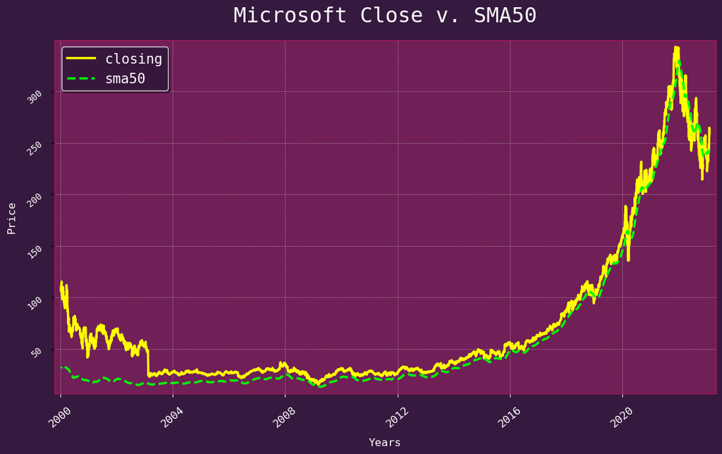

```python
plot_lines([(msft.close, 'closing', 'yellow'),
		    (msft.sma50, 'sma50', 'lime')],
		   title = 'Microsoft Close v. SMA50',
		   xlabel = 'Years',
		   ylabel = 'Price')
```

| Bollinger Bands |  |  |
| --- | --- | --- |
| - Middle Band is the same as the SMA50 - Lower is minus 2 std from the SMA - Upper is plus 2 std from the SMA |  |  |

```python
pretty('indicator.get_bbands()')
help(indicator.get_bbands)
```

| indicator.get_bbands() |
| --- |

```
Help on method get_bbands in module alpha_vantage.techindicators:

get_bbands(symbol, interval='daily', time_period=20, series_type='close', nbdevup=None, nbdevdn=None, matype=None) method of alpha_vantage.techindicators.TechIndicators instance
    Return the bollinger bands values in two
    json objects as data and meta_data. It raises ValueError when problems
    arise

    Keyword Arguments:
        symbol:  the symbol for the equity we want to get its data
        interval:  time interval between two conscutive values,
            supported values are '1min', '5min', '15min', '30min', '60min', 'daily',
            'weekly', 'monthly' (default 'daily')
        time_period:  Number of data points used to calculate each BBANDS value.
            Positive integers are accepted (e.g., time_period=60, time_period=200)
            (default=20)
        series_type:  The desired price type in the time series. Four types
            are supported: 'close', 'open', 'high', 'low' (default 'close')
        nbdevup:  The standard deviation multiplier of the upper band. Positive
            integers are accepted as default (default=2)
        nbdevdn:  The standard deviation multiplier of the lower band. Positive
            integers are accepted as default (default=2)
        matype :  Moving average type. By default, matype=0.
            Integers 0 - 8 are accepted (check  down the mappings) or the string
            containing the math type can also be used.

            * 0 = Simple Moving Average (SMA),
            * 1 = Exponential Moving Average (EMA),
            * 2 = Weighted Moving Average (WMA),
            * 3 = Double Exponential Moving Average (DEMA),
            * 4 = Triple Exponential Moving Average (TEMA),
            * 5 = Triangular Moving Average (TRIMA),
            * 6 = T3 Moving Average,
            * 7 = Kaufman Adaptive Moving Average (KAMA),
            * 8 = MESA Adaptive Moving Average (MAMA)
```

```python
bollinger = indicator.get_bbands('MSFT', interval = 'daily', time_period = 50)[0]
```

```python
pretty('bollinger meta informtation')
indicator.get_bbands('MSFT', interval = 'daily', time_period = 50)[1]
```

| bollinger meta informtation |
| --- |

```
{'1: Symbol': 'MSFT',
 '2: Indicator': 'Bollinger Bands (BBANDS)',
 '3: Last Refreshed': '2023-02-03',
 '4: Interval': 'daily',
 '5: Time Period': 50,
 '6.1: Deviation multiplier for upper band': 2,
 '6.2: Deviation multiplier for lower band': 2,
 '6.3: MA Type': 0,
 '7: Series Type': 'close',
 '8: Time Zone': 'US/Eastern Time'}
```

```python
head_tail_horz(bollinger, 5, "Bollinger Bands")
```

| Bollinger Bands |
| --- |

head(5)

| date | Real Upper Band | Real Middle Band | Real Lower Band |
| --- | --- | --- | --- |
| 2023-02-03 | 260.65 | 243.14 | 225.64 |
| 2023-02-02 | 259.78 | 242.82 | 225.86 |
| 2023-02-01 | 258.13 | 242.35 | 226.57 |
| 2023-01-31 | 257.62 | 242.13 | 226.63 |
| 2023-01-30 | 257.42 | 242.01 | 226.59 |

tail(5)

| date | Real Upper Band | Real Middle Band | Real Lower Band |
| --- | --- | --- | --- |
| 2000-01-18 | 39.26 | 31.80 | 24.33 |
| 2000-01-14 | 39.06 | 31.65 | 24.24 |
| 2000-01-13 | 38.90 | 31.52 | 24.14 |
| 2000-01-12 | 38.81 | 31.43 | 24.04 |
| 2000-01-11 | 38.74 | 31.34 | 23.94 |

| *# combining with Microsoft close and SMA50* |  |  |
| --- | --- | --- |

```python
msft_full = msft.merge(bollinger,
					   how = 'left',
					   left_on = 'date',
					   right_on = 'date').drop(columns = ['Real Middle Band'])
msft_full.columns = ['close', 'sma50', 'upper_bband', 'lower_bband']
```

```python
head_tail_vert(msft_full, 3, 'Microsoft Data with Upper & Lower Bollinger Bands')
```

| Microsoft Data with Upper & Lower Bollinger Bands: head(3) |
| --- |

| date | close | sma50 | upper_bband | lower_bband |
| --- | --- | --- | --- | --- |
| 2023-02-03 | 258.35 | 243.14 | 260.65 | 225.64 |
| 2023-02-02 | 264.60 | 242.82 | 259.78 | 225.86 |
| 2023-02-01 | 252.75 | 242.35 | 258.13 | 226.57 |

| Microsoft Data with Upper & Lower Bollinger Bands: tail(3) |
| --- |

| date | close | sma50 | upper_bband | lower_bband |
| --- | --- | --- | --- | --- |
| 2000-01-13 | 107.81 | 31.52 | 38.90 | 24.14 |
| 2000-01-12 | 105.81 | 31.43 | 38.81 | 24.04 |
| 2000-01-11 | 109.37 | 31.34 | 38.74 | 23.94 |

[output not shown]

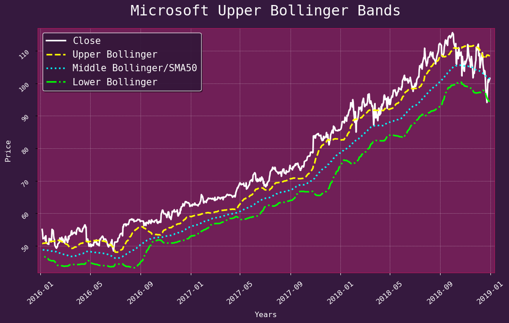

```python
plot_lines([(msft_full.loc['2016-01-05':'2018-12-31'].close,
			 'Close', 'white'),
			(msft_full.loc['2016-01-05':'2018-12-31'].upper_bband,
			 'Upper Bollinger', 'yellow'),
			(msft_full.loc['2016-01-05':'2018-12-31'].sma50,
			 'Middle Bollinger/SMA50', 'cyan'),
		    (msft_full.loc['2016-01-05':'2018-12-31'].lower_bband,
			 'Lower Bollinger', 'lime')],
		   title = 'Microsoft Upper Bollinger Bands',
		   xlabel = 'Years',
		   ylabel = 'Price')
```

| *macd* - moving average convergence divergence |  |  |
| --- | --- | --- |

[**(from Investopedia)**](https://www.investopedia.com/terms/m/macd.asp)

Moving average convergence/divergence (MACD, or MAC-D) is a trend-following momentum indicator that shows the relationship between two exponential moving averages (EMAs) of a security’s price. The MACD line is calculated by subtracting the 26-period EMA from the 12-period EMA.

The result of that calculation is the MACD line. A nine-day EMA of the MACD line is called the signal line, which is then plotted on top of the MACD line, which can function as a trigger for buy or sell signals. Traders may buy the security when the MACD line crosses above the signal line and sell—or short—the security when the MACD line crosses below the signal line. MACD indicators can be interpreted in several ways, but the more common methods are crossovers, divergences, and rapid rises/falls.

```python
pretty('indicator.get_macd()')
help(indicator.get_macd)
```

| indicator.get_macd() |
| --- |

```
Help on method get_macd in module alpha_vantage.techindicators:

get_macd(symbol, interval='daily', series_type='close', fastperiod=None, slowperiod=None, signalperiod=None) method of alpha_vantage.techindicators.TechIndicators instance
    Return the moving average convergence/divergence time series in two
    json objects as data and meta_data. It raises ValueError when problems
    arise

    Keyword Arguments:
        symbol:  the symbol for the equity we want to get its data
        interval:  time interval between two conscutive values,
            supported values are '1min', '5min', '15min', '30min', '60min', 'daily',
            'weekly', 'monthly' (default 'daily'
        series_type:  The desired price type in the time series. Four types
            are supported: 'close', 'open', 'high', 'low' (default 'close')
        fastperiod:  Positive integers are accepted (default=None)
        slowperiod:  Positive integers are accepted (default=None)
        signalperiod:  Positive integers are accepted (default=None)
```

```python
macd = indicator.get_macd('MSFT', interval = 'daily')[0]
```

```python
pretty('macd meta informtation')
indicator.get_macd('MSFT', interval = 'daily')[1]
```

| macd meta informtation |
| --- |

```
{'1: Symbol': 'MSFT',
 '2: Indicator': 'Moving Average Convergence/Divergence (MACD)',
 '3: Last Refreshed': '2023-02-03',
 '4: Interval': 'daily',
 '5.1: Fast Period': 12,
 '5.2: Slow Period': 26,
 '5.3: Signal Period': 9,
 '6: Series Type': 'close',
 '7: Time Zone': 'US/Eastern'}
```

```python
head_tail_horz(macd, 5, 'Moving Average Convergence Divergence')
```

| Moving Average Convergence Divergence |
| --- |

head(5)

| date | MACD | MACD_Signal | MACD_Hist |
| --- | --- | --- | --- |
| 2023-02-03 | 4.56 | 2.00 | 2.56 |
| 2023-02-02 | 3.95 | 1.36 | 2.59 |
| 2023-02-01 | 2.48 | 0.71 | 1.77 |
| 2023-01-31 | 1.78 | 0.26 | 1.51 |
| 2023-01-30 | 1.36 | -0.12 | 1.47 |

tail(5)

| date | MACD | MACD_Signal | MACD_Hist |
| --- | --- | --- | --- |
| 1999-12-23 | 2.24 | 1.52 | 0.71 |
| 1999-12-22 | 2.13 | 1.34 | 0.79 |
| 1999-12-21 | 1.97 | 1.15 | 0.82 |
| 1999-12-20 | 1.78 | 0.94 | 0.84 |
| 1999-12-17 | 1.61 | 0.73 | 0.88 |

| *# combining with Microsoft close and MACDs* |  |  |
| --- | --- | --- |

```python
msft_full = msft_full.merge(macd,
					   how = 'left',
					   left_on = 'date',
					   right_on = 'date')
```

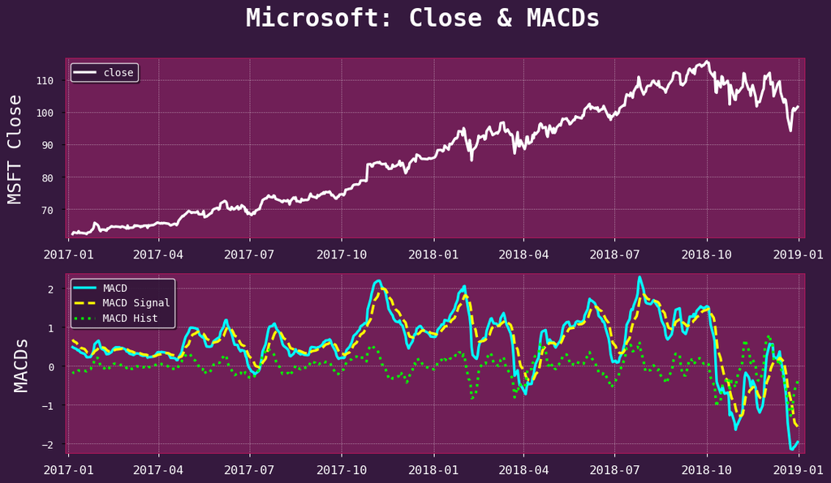

```python
plt.style.use('pinks.mplstyle')
fig, axs = plt.subplots(2)
fig.suptitle('Vertically stacked subplots')
axs[0].plot(msft_full.loc['2017-01-05':'2018-12-31'].close,
			 label = 'close', color = 'white');
axs[0].set_ylabel('MSFT Close')
axs[0].legend(loc = 2, fontsize = 10);
axs[1].plot(msft_full.loc['2017-01-05':'2018-12-31'].MACD,
			label = 'MACD', color = 'cyan');
axs[1].plot(msft_full.loc['2017-01-05':'2018-12-31'].MACD_Signal,
			 label = 'MACD Signal', color = 'yellow');
axs[1].plot(msft_full.loc['2017-01-05':'2018-12-31'].MACD_Hist,
			 label = 'MACD Hist', color = 'lime');
axs[1].legend(loc = 2, fontsize = 10);
axs[1].set_ylabel('MACDs');
plt.suptitle('Microsoft: Close & MACDs');
```

| \| Top \| Getting Data \| Splits & Dividends \| The Datetime Index \| Frequency & Intervals \| Technical Indicators \| Foreign Exchange \| Cryptocurrencies \| |  |  |
| --- | --- | --- |

| Currencies / Foreign Exchanges |  |  |
| --- | --- | --- |

```python
from alpha_vantage.foreignexchange import ForeignExchange
```

```python
foreign = ForeignExchange(key = api_key, output_format = 'pandas')
```

```python
pretty('ForeignExchange()')
help(foreign)
```

| ForeignExchange() |
| --- |

```
Help on ForeignExchange in module alpha_vantage.foreignexchange object:

class ForeignExchange(alpha_vantage.alphavantage.AlphaVantage)
 |  ForeignExchange(*args, **kwargs)
 |  Realtime currency exchange rates for physical and digital currencies.
 |  Method resolution order:
 |      ForeignExchange
 |      alpha_vantage.alphavantage.AlphaVantage
 |      builtins.object
 |  Methods defined here:
 |  __init__(self, *args, **kwargs)
 |      Inherit AlphaVantage base class with its default arguments
 |  get_currency_exchange_daily(self, from_symbol, to_symbol, outputsize='compact')
 |      Returns the daily exchange rate for any pair of physical
 |      currency (e.g., EUR) or physical currency (e.g., USD).
 |      Keyword Arguments:
 |          from_symbol: The currency you would like to get the exchange rate
 |              for.
 |              For example: from_symbol=EUR or from_symbol=USD.
 |          to_symbol: The destination currency for the exchange rate.
 |              For example: to_symbol=USD or to_symbol=JPY.
 |          outputsize:  The size of the call, supported values are
 |              'compact' and 'full; the first returns the last 100 points in the
 |              data series, and 'full' returns the full-length daily times
 |              series, commonly above 1MB (default 'compact')
 |  get_currency_exchange_intraday(self, from_symbol, to_symbol, interval='15min', outputsize='compact')
 |      Returns the intraday exchange rate for any pair of physical
 |      currency (e.g., EUR) or physical currency (e.g., USD).
 |      Keyword Arguments:
 |          from_symbol: The currency you would like to get the exchange rate
 |              for.
 |              For example: from_currency=EUR or from_currency=USD.
 |          to_symbol: The destination currency for the exchange rate.
 |              For example: to_currency=USD or to_currency=JPY.
 |          interval:  time interval between two conscutive values,
 |              supported values are '1min', '5min', '15min', '30min', '60min'
 |              (default '15min')
 |          outputsize:  The size of the call, supported values are
 |              'compact' and 'full; the first returns the last 100 points in the
 |              data series, and 'full' returns the full-length intraday times
```

[output cut: 55 more lines]

```
 |              * 5 = Triangular Moving Average (TRIMA),
 |              * 6 = T3 Moving Average,
 |              * 7 = Kaufman Adaptive Moving Average (KAMA),
 |              * 8 = MESA Adaptive Moving Average (MAMA)
 |  set_proxy(self, proxy=None)
 |      Set a new proxy configuration
 |      Keyword Arguments:
 |          proxy: Dictionary mapping protocol or protocol and hostname to
 |          the URL of the proxy.
 |  ----------------------------------------------------------------------
 |  Data descriptors inherited from alpha_vantage.alphavantage.AlphaVantage:
 |  __dict__
 |      dictionary for instance variables (if defined)
 |  __weakref__
 |      list of weak references to the object (if defined)
```

[output not shown]

```python
eur_usd = foreign.get_currency_exchange_daily('USD', 'EUR', outputsize = 'full')[0]
```

```python
pretty('foreign.get_currency_exchange_daily()')
help(foreign.get_currency_exchange_daily)
```

| foreign.get_currency_exchange_daily() |
| --- |

```
Help on method get_currency_exchange_daily in module alpha_vantage.foreignexchange:

get_currency_exchange_daily(from_symbol, to_symbol, outputsize='compact') method of alpha_vantage.foreignexchange.ForeignExchange instance
    Returns the daily exchange rate for any pair of physical
    currency (e.g., EUR) or physical currency (e.g., USD).

    Keyword Arguments:
        from_symbol: The currency you would like to get the exchange rate
            for.
            For example: from_symbol=EUR or from_symbol=USD.
        to_symbol: The destination currency for the exchange rate.
            For example: to_symbol=USD or to_symbol=JPY.
        outputsize:  The size of the call, supported values are
            'compact' and 'full; the first returns the last 100 points in the
            data series, and 'full' returns the full-length daily times
            series, commonly above 1MB (default 'compact')
```

```python
pretty('usd_eur meta information')
foreign.get_currency_exchange_daily('USD', 'EUR', outputsize = 'full')[1]
```

| usd_eur meta information |
| --- |

```
{'1. Information': 'Forex Daily Prices (open, high, low, close)',
 '2. From Symbol': 'USD',
 '3. To Symbol': 'EUR',
 '4. Output Size': 'Full size',
 '5. Last Refreshed': '2023-02-03 21:55:00',
 '6. Time Zone': 'UTC'}
```

```python
head_tail_horz(eur_usd, 3, 'Euro to USD')
```

[output not shown]

head(3)

| date | 1. open | 2. high | 3. low | 4. close |
| --- | --- | --- | --- | --- |
| 2023-02-03 | 0.92 | 0.93 | 0.91 | 0.93 |
| 2023-02-02 | 0.91 | 0.92 | 0.91 | 0.92 |
| 2023-02-01 | 0.92 | 0.92 | 0.91 | 0.91 |

tail(3)

| date | 1. open | 2. high | 3. low | 4. close |
| --- | --- | --- | --- | --- |
| 2014-11-26 | 0.80 | 0.80 | 0.80 | 0.80 |
| 2014-11-25 | 0.80 | 0.81 | 0.80 | 0.80 |
| 2014-11-24 | 0.81 | 0.81 | 0.80 | 0.80 |

| *# USD to Euro* |  |  |
| --- | --- | --- |

```python
usd_eur = foreign.get_currency_exchange_intraday('USD', 'EUR', outputsize = 'full')[0]
```

```python
pretty('foreign.get_currency_exchange_intraday()')
help(foreign.get_currency_exchange_intraday)
```

| foreign.get_currency_exchange_intraday() |
| --- |

```
Help on method get_currency_exchange_intraday in module alpha_vantage.foreignexchange:

get_currency_exchange_intraday(from_symbol, to_symbol, interval='15min', outputsize='compact') method of alpha_vantage.foreignexchange.ForeignExchange instance
    Returns the intraday exchange rate for any pair of physical
    currency (e.g., EUR) or physical currency (e.g., USD).

    Keyword Arguments:
        from_symbol: The currency you would like to get the exchange rate
            for.
            For example: from_currency=EUR or from_currency=USD.
        to_symbol: The destination currency for the exchange rate.
            For example: to_currency=USD or to_currency=JPY.
        interval:  time interval between two conscutive values,
            supported values are '1min', '5min', '15min', '30min', '60min'
            (default '15min')
        outputsize:  The size of the call, supported values are
            'compact' and 'full; the first returns the last 100 points in the
            data series, and 'full' returns the full-length intraday times
            series, commonly above 1MB (default 'compact')
```

```python
pretty('foreign.usd_eur meta information')
foreign.get_currency_exchange_intraday('USD', 'EUR', outputsize = 'full')[1]
```

| foreign.usd_eur meta information |
| --- |

```
{'1. Information': 'FX Intraday (15min) Time Series',
 '2. From Symbol': 'USD',
 '3. To Symbol': 'EUR',
 '4. Last Refreshed': '2023-02-03 21:45:00',
 '5. Interval': '15min',
 '6. Output Size': 'Full size',
 '7. Time Zone': 'UTC'}
```

```python
head_tail_horz(usd_eur, 3, 'USD to EUR')
```

| USD to EUR |
| --- |

head(3)

| date | 1. open | 2. high | 3. low | 4. close |
| --- | --- | --- | --- | --- |
| 2023-02-03 | 0.93 | 0.93 | 0.93 | 0.93 |
| 2023-02-03 | 0.93 | 0.93 | 0.93 | 0.93 |
| 2023-02-03 | 0.93 | 0.93 | 0.93 | 0.93 |

tail(3)

| date | 1. open | 2. high | 3. low | 4. close |
| --- | --- | --- | --- | --- |
| 2023-01-20 | 0.92 | 0.92 | 0.92 | 0.92 |
| 2023-01-20 | 0.92 | 0.92 | 0.92 | 0.92 |
| 2023-01-20 | 0.92 | 0.92 | 0.92 | 0.92 |

| *# Euro to USD intraday, 60 min* |  |  |
| --- | --- | --- |

```python
see(foreign.get_currency_exchange_intraday('EUR', 'USD',
										   interval = '60min',
										   outputsize = 'full')[0].head(5),
	'EUR-USD Intraday: 60 min')
```

| EUR-USD Intraday: 60 min |
| --- |

| date | 1. open | 2. high | 3. low | 4. close |
| --- | --- | --- | --- | --- |
| 2023-02-03 | 1.08 | 1.08 | 1.08 | 1.08 |
| 2023-02-03 | 1.08 | 1.08 | 1.08 | 1.08 |
| 2023-02-03 | 1.08 | 1.08 | 1.08 | 1.08 |
| 2023-02-03 | 1.08 | 1.08 | 1.08 | 1.08 |
| 2023-02-03 | 1.09 | 1.09 | 1.08 | 1.08 |

| *# USD to Euro intraday, 1 min* |  |  |
| --- | --- | --- |

```python
see(foreign.get_currency_exchange_intraday('USD', 'EUR',
										   interval = '1min',
										   outputsize = 'full')[0].head(5),
	'USD-EUR Intraday: 1 min')
```

| USD-EUR Intraday: 1 min |
| --- |

| date | 1. open | 2. high | 3. low | 4. close |
| --- | --- | --- | --- | --- |
| 2023-02-03 | 0.93 | 0.93 | 0.93 | 0.93 |
| 2023-02-03 | 0.93 | 0.93 | 0.93 | 0.93 |
| 2023-02-03 | 0.93 | 0.93 | 0.93 | 0.93 |
| 2023-02-03 | 0.93 | 0.93 | 0.93 | 0.93 |
| 2023-02-03 | 0.93 | 0.93 | 0.93 | 0.93 |

| CURRENCIES PLAYGROUND: |  |  |
| --- | --- | --- |

```python
currencies = pd.read_csv('https://mydatabucky.s3.amazonaws.com/global_currencies.csv')[['country', 'currency_name', 'currency_code']]
```

```python
df_overview(currencies)
```

DataFrame Columns

|  | country | currency_name | currency_code |
| --- | --- | --- | --- |
| datatype | object | object | object |
| missing values | 0 | 0 | 0 |
| count | 272 | 272 | 272 |
| unique | 254 | 172 | 174 |
| top | SWITZERLAND | Euro | EUR |
| freq | 3 | 36 | 36 |

DataFrame Key Points

| total rows | 272 |
| --- | --- |
| total columns | 3 |
| column names | country, currency_name, currency_code |
| index start | 0 |
| index end | 271 |
| total missing values | 0 |

| DataFrame Head and Tail |
| --- |

head(3)

|  | country | currency_name | currency_code |
| --- | --- | --- | --- |
| 0 | AFGHANISTAN | Afghani | AFN |
| 1 | ÅLAND ISLANDS | Euro | EUR |
| 2 | ALBANIA | Lek | ALL |

tail(3)

|  | country | currency_name | currency_code |
| --- | --- | --- | --- |
| 269 | Palladium | Palladium | XPD |
| 270 | Platinum | Platinum | XPT |
| 271 | Silver | Silver | XAG |

```python
currencies[currencies.country.str.startswith('R')]
```

|  | country | currency_name | currency_code |
| --- | --- | --- | --- |
| 193 | RÉUNION | Euro | EUR |
| 194 | ROMANIA | Romanian Leu | RON |
| 195 | RUSSIAN FEDERATION (THE) | Russian Ruble | RUB |
| 196 | RWANDA | Rwanda Franc | RWF |

| *exchange_rate(from_currency, to_currency)* |  |  |
| --- | --- | --- |

```python
def exchange_rate(from_currency, to_currency):
	import requests

	# replace the "demo" apikey below with your own key from https://www.alphavantage.co/support/#api-key
	url = f'https://www.alphavantage.co/query?function=CURRENCY_EXCHANGE_RATE&from_currency={from_currency}&to_currency={to_currency}&apikey=X'
	r = requests.get(url)
	data = r.json()

	results = pd.DataFrame(pd.Series(data['Realtime Currency Exchange Rate']))
	results = results.drop(labels = ['1. From_Currency Code', '3. To_Currency Code'],
						   axis = 0)
	results.index = ['From Currency', 'To Currency', 'Exchange Rate', 'Last Refreshed',
					 'Time Zone', 'Bid Price', 'Ask Price']
	results = results.reset_index()

	styles = [{'selector': '.col0',
							'props': [('font-size', '13px'),
									  ('text-align', 'left'),
									  ('padding-right', '15px'),
									  ('font-weight', 'bold')]},
		     {'selector': '.col1',
					'props': [('font-weight', 'medium'),
							('text-align', 'left'),
							('font-size', '13px'),
							('padding-right', '15px'),
							('padding-left', '15px')]},
			 {'selector': 'caption',
					'props': [('font-weight', 'bold'),
							('font-size', '23px'),]},
			 {'selector': '.row2',
					'props': [('font-weight', 'bold'),
							('background-color', 'cyan'),]}]


	display(results.style.hide(axis = 'index')\
						 .hide(axis = 'columns')\
						 .set_caption('Exchange Results')\
						 .set_table_attributes("style='margin-left: auto;\
													   margin-right: auto;'")\
					     .set_table_styles(styles).format(precision = 2,
														  thousands = ','))
```

```python
results = exchange_rate('USD', 'EUR')
```

Exchange Results

| From Currency | United States Dollar |
| --- | --- |
| To Currency | Euro |
| Exchange Rate | 0.92610000 |
| Last Refreshed | 2023-02-04 19:51:44 |
| Time Zone | UTC |
| Bid Price | 0.92609000 |
| Ask Price | 0.92613000 |

| \| Top \| Getting Data \| Splits & Dividends \| The Datetime Index \| Frequency & Intervals \| Technical Indicators \| Foreign Exchange \| Cryptocurrencies \| |  |  |
| --- | --- | --- |

| Cryptocurrencies |  |  |
| --- | --- | --- |
| - Alpha Vantage offers data on over 500 cryptocurrencies |  |  |

```python
from alpha_vantage.cryptocurrencies import CryptoCurrencies
```

```python
crypto = CryptoCurrencies(key = api_key, output_format = 'pandas')
```

```python
crypto
```

```
<alpha_vantage.cryptocurrencies.CryptoCurrencies at 0x7fb7b02d6380>
```

| *Bitcoin to USD* |  |  |
| --- | --- | --- |

```python
BTC = crypto.get_digital_currency_daily(symbol = 'BTC', market = 'USD')
```

```python
pretty('BTC to USD meta data')
BTC[1]
```

| BTC to USD meta data |
| --- |

```
{'1. Information': 'Daily Prices and Volumes for Digital Currency',
 '2. Digital Currency Code': 'BTC',
 '3. Digital Currency Name': 'Bitcoin',
 '4. Market Code': 'USD',
 '5. Market Name': 'United States Dollar',
 '6. Last Refreshed': '2023-02-04 00:00:00',
 '7. Time Zone': 'UTC'}
```

```python
see(BTC[0].head(5),
   'Most Recent Bitcoin Data')
```

| Most Recent Bitcoin Data |
| --- |

| date | 1a. open (USD) | 1b. open (USD) | 2a. high (USD) | 2b. high (USD) | 3a. low (USD) | 3b. low (USD) | 4a. close (USD) | 4b. close (USD) | 5. volume | 6. market cap (USD) |
| --- | --- | --- | --- | --- | --- | --- | --- | --- | --- | --- |
| 2023-02-04 | 23,431.90 | 23,431.90 | 23,465.15 | 23,465.15 | 23,382.01 | 23,382.01 | 23,435.65 | 23,435.65 | 11,789.15 | 11,789.15 |
| 2023-02-03 | 23,489.33 | 23,489.33 | 23,715.70 | 23,715.70 | 23,204.62 | 23,204.62 | 23,431.90 | 23,431.90 | 332,571.03 | 332,571.03 |
| 2023-02-02 | 23,731.41 | 23,731.41 | 24,255.00 | 24,255.00 | 23,363.27 | 23,363.27 | 23,488.94 | 23,488.94 | 364,177.21 | 364,177.21 |
| 2023-02-01 | 23,125.13 | 23,125.13 | 23,812.66 | 23,812.66 | 22,760.23 | 22,760.23 | 23,732.66 | 23,732.66 | 310,790.42 | 310,790.42 |
| 2023-01-31 | 22,827.38 | 22,827.38 | 23,320.00 | 23,320.00 | 22,714.77 | 22,714.77 | 23,125.13 | 23,125.13 | 264,649.35 | 264,649.35 |

| *Bitcoin to Euro* |  |  |
| --- | --- | --- |

```python
BTC = crypto.get_digital_currency_daily(symbol = 'BTC', market = 'EUR')
pretty('BTC to EUR meta data')
BTC[1]
```

| BTC to EUR meta data |
| --- |

```
{'1. Information': 'Daily Prices and Volumes for Digital Currency',
 '2. Digital Currency Code': 'BTC',
 '3. Digital Currency Name': 'Bitcoin',
 '4. Market Code': 'EUR',
 '5. Market Name': 'Euro',
 '6. Last Refreshed': '2023-02-04 00:00:00',
 '7. Time Zone': 'UTC'}
```

```python
see(BTC[0].head(5),
   'Bitcoin to Euro (keeping USD market data)')
```

| Bitcoin to Euro (keeping USD market data) |
| --- |

| date | 1a. open (EUR) | 1b. open (USD) | 2a. high (EUR) | 2b. high (USD) | 3a. low (EUR) | 3b. low (USD) | 4a. close (EUR) | 4b. close (USD) | 5. volume | 6. market cap (USD) |
| --- | --- | --- | --- | --- | --- | --- | --- | --- | --- | --- |
| 2023-02-04 | 21,702.63 | 23,431.90 | 21,733.42 | 23,465.15 | 21,656.42 | 23,382.01 | 21,706.42 | 23,436.00 | 11,788.53 | 11,788.53 |
| 2023-02-03 | 21,755.82 | 23,489.33 | 21,965.48 | 23,715.70 | 21,492.12 | 23,204.62 | 21,702.63 | 23,431.90 | 332,571.03 | 332,571.03 |
| 2023-02-02 | 21,980.03 | 23,731.41 | 22,464.98 | 24,255.00 | 21,639.06 | 23,363.27 | 21,755.46 | 23,488.94 | 364,177.21 | 364,177.21 |
| 2023-02-01 | 21,418.50 | 23,125.13 | 22,055.29 | 23,812.66 | 21,080.53 | 22,760.23 | 21,981.19 | 23,732.66 | 310,790.42 | 310,790.42 |
| 2023-01-31 | 21,142.72 | 22,827.38 | 21,598.98 | 23,320.00 | 21,038.42 | 22,714.77 | 21,418.50 | 23,125.13 | 264,649.35 | 264,649.35 |

| *Ethereum* |  |  |
| --- | --- | --- |

```python
pretty('ETH meta data')
crypto.get_digital_currency_daily(symbol = 'ETH', market = 'USD')[1]
```

| ETH meta data |
| --- |

```
{'1. Information': 'Daily Prices and Volumes for Digital Currency',
 '2. Digital Currency Code': 'ETH',
 '3. Digital Currency Name': 'Ethereum',
 '4. Market Code': 'USD',
 '5. Market Name': 'United States Dollar',
 '6. Last Refreshed': '2023-02-04 00:00:00',
 '7. Time Zone': 'UTC'}
```

```python
see(crypto.get_digital_currency_daily(symbol = 'ETH', market = 'USD')[0].head(5),
   'Most Current Ethereum Data')
```

| Most Current Ethereum Data |
| --- |

| date | 1a. open (USD) | 1b. open (USD) | 2a. high (USD) | 2b. high (USD) | 3a. low (USD) | 3b. low (USD) | 4a. close (USD) | 4b. close (USD) | 5. volume | 6. market cap (USD) |
| --- | --- | --- | --- | --- | --- | --- | --- | --- | --- | --- |
| 2023-02-04 | 1,663.52 | 1,663.52 | 1,665.95 | 1,665.95 | 1,658.01 | 1,658.01 | 1,663.09 | 1,663.09 | 18,334.72 | 18,334.72 |
| 2023-02-03 | 1,643.12 | 1,643.12 | 1,676.00 | 1,676.00 | 1,625.93 | 1,625.93 | 1,663.52 | 1,663.52 | 464,815.03 | 464,815.03 |
| 2023-02-02 | 1,641.67 | 1,641.67 | 1,714.68 | 1,714.68 | 1,626.85 | 1,626.85 | 1,643.12 | 1,643.12 | 629,188.89 | 629,188.89 |
| 2023-02-01 | 1,585.32 | 1,585.32 | 1,647.77 | 1,647.77 | 1,555.18 | 1,555.18 | 1,641.68 | 1,641.68 | 474,617.17 | 474,617.17 |
| 2023-01-31 | 1,566.21 | 1,566.21 | 1,605.18 | 1,605.18 | 1,561.63 | 1,561.63 | 1,585.33 | 1,585.33 | 348,856.68 | 348,856.68 |

| \| Top \| Getting Data \| Splits & Dividends \| The Datetime Index \| Frequency & Intervals \| Technical Indicators \| Foreign Exchange \| Cryptocurrencies \| |  |  |
| --- | --- | --- |